# Esports Part 1: Data Acquisition and Formatting

LoL, SC2, and Chess

2024-07-04

# Packages

```r
library(jsonlite)
library(stringr)
library(tidyverse)
library(ggplot2)
library(bigchess)
library(chessR)
```

# League of Legends

League of Legends, on the competitive scene, is played as a 5v5 team game in which each player controls one hero. It’s the largest game in the MOBA genre, and is played for millions of dollars each year.

We can access detailed information about the matched played at any level through an API.

[figure not shown]

# LoL: Sources

For general information about using the API

https://developer.riotgames.com/docs/lol

You need a Riot account. If you want to do more than the basic API stuff, you need to submit a proposal to Riot.

https://developer.riotgames.com/docs/portal#_getting-started

For specific API calls, see this link

https://developer.riotgames.com/apis

This is a very handy video series on the use of the API, last updated in early 2024.

https://www.youtube.com/playlist?list=PLnnM9dgSdUvIe0MRJcjbzBaJWFHNJaOh1

# LoL: Getting your API key

First we need to refresh our API key, because the basic developer one needs to be manually re-generated for every 24 hours you plan to use it. There are longer-lived keys for the development of applications and websites that regularly need data from Riot Games, but you need to propose a project to Riot Games for that higher level access.

To get this key, you simply need a Riot account. You don’t even need to play or install a game.

Technically, this key is supposed to remain secret because who has it can impersonate you. However, this key will have expired by the time this talk goes live.

To get a new API key: https://developer.riotgames.com/

[figure not shown]

```r
my_api_key = "RGAPI-ca5c9e2d-ac68-4984-a6ee-658876685416"
```

# LoL: Finding a specific match

From: https://developer.riotgames.com/apis#league-v4/

We can get all the league entries with the API call

`/lol/league/v4/entries/{queue}/{tier}/{division}`

```r
possible_division = c("I","II","III","IV")
possible_tier = c("DIAMOND","EMERALD","PLATINUM","GOLD","SILVER","BRONZE","IRON")

# To get a new API key: https://developer.riotgames.com/
pagenum = 1
possible_region = c("na1","br1")

testing <- fromJSON("https://br1.api.riotgames.com/lol/league/v4/entries/RANKED_SOLO_5x5/DIAMOND/I?page=1&api_key=RGAPI-ca5c9e2d-ac68-4984-a6ee-658876685416")
head(testing)
```

```
##                               leagueId       queueType    tier rank
## 1 71aa5d8a-9b76-4cba-aa41-5a91450be78d RANKED_SOLO_5x5 DIAMOND    I
## 2 e8109f10-b54b-4bab-812b-907826eefd59 RANKED_SOLO_5x5 DIAMOND    I
## 3 3f845a69-2304-4407-8f11-630996ec738b RANKED_SOLO_5x5 DIAMOND    I
## 4 1f451ad0-98e9-4c55-ada2-e307baea2df1 RANKED_SOLO_5x5 DIAMOND    I
## 5 55a6df85-c37c-4862-a670-373c3ddc3b6a RANKED_SOLO_5x5 DIAMOND    I
## 6 a2916725-2be4-4597-bb6e-f4939b26bdfd RANKED_SOLO_5x5 DIAMOND    I
##                                        summonerId leaguePoints wins losses
## 1 urWCNPaHR6eEb7RZa617howInesWztfGLAeZXrphvrkS48I            8   28     15
## 2 1SEfWV5AhhwpNpTFrU5aa-deNne2vuHGQPfWTEk-QSpeMUI           23   49     48
## 3 fNPu5JadSQBZ8W97RiIzrInsPJHGLLY6yEBJbdDkHdLomHE           75   11      6
## 4 zTl_qofFCWVnye_9zSDrahmhmmvryEoMSFOPZIHpy5C4m4w           77   16     12
## 5 _10Kx9sj95OO6nnPxWBlws4dxoFZXXPvkSuHDC3MB3LznNw           11   11      6
## 6 qt_CeKpKfmxW1PHryX_EwXeCenbXjB60I31I60a2P8F1XVQ           41  106    110
##   veteran inactive freshBlood hotStreak
## 1   FALSE    FALSE      FALSE     FALSE
## 2   FALSE    FALSE      FALSE     FALSE
## 3   FALSE    FALSE      FALSE      TRUE
## 4   FALSE    FALSE      FALSE      TRUE
## 5   FALSE    FALSE      FALSE     FALSE
## 6   FALSE    FALSE       TRUE     FALSE
```

# LoL: Finding a specific match

We can get multiple pages from Diamond I, one of the highest tiers of play in the game.

```r
my_tier = "DIAMOND"
my_div = "I"
my_region = "na1"

for(k in 1:5)
{

  api_call_url = paste0("https://",
                        my_region,
                        ".api.riotgames.com/lol/league/v4/entries/RANKED_SOLO_5x5/",
                        my_tier,"/",
                        my_div,"?page=",
                        k,"&api_key=",
                        my_api_key)

  this_page = fromJSON(api_call_url)

  if(k == 1)
  {
    all_pages = this_page
  }

  if(k > 1)
  {
    all_pages = rbind(all_pages, this_page)

  }

  Sys.sleep(2)

}
```

# LoL: Finding a specific match

Here we are looking at the matches from these 5 pages from highest to lowest ranking within Diamond I (as shown by `leaguePoints`)

```r
all_pages = all_pages[rev(order(all_pages$leaguePoints)), ]

dim(all_pages)
```

```
## [1] 1025   12
```

```r
head(all_pages) # Best in Diamond I
```

```
##                                 leagueId       queueType    tier rank
## 887 86260907-e5c4-49c5-aac5-7ecb146392b6 RANKED_SOLO_5x5 DIAMOND    I
## 293 dbd3cc6c-f900-45c1-ad85-c6f883e4bd09 RANKED_SOLO_5x5 DIAMOND    I
## 178 22fdc9d8-b827-408b-9220-998a9903404a RANKED_SOLO_5x5 DIAMOND    I
## 875 795c6447-c482-4122-9aca-4f49fb504a1c RANKED_SOLO_5x5 DIAMOND    I
## 230 44a0b955-6407-4fa9-894d-54a6f1aee448 RANKED_SOLO_5x5 DIAMOND    I
## 550 594d812b-dabf-4869-bf8d-2440eda37cd8 RANKED_SOLO_5x5 DIAMOND    I
##                                           summonerId leaguePoints wins losses
## 887  uXaDrLppbnMyCgZ2My3S0rHuatsn4Gy5Xh8d04DPMDD2GkA           99   15      7
## 293 wjrPfBkAGyEj5-Fbx0IOzlanQoS8pMYdWq65bJMuKAVQxUHW           99   18      6
## 178 76MmqJo1g4k20hcF6MPrAz0fH1504tY14NczOyw958lKb_r8           99   62     56
## 875  RiGnarIYDglfdg0muNWO2EMfw2J4gQYCqilxRfumpUETYzU           98   31     31
## 230 taIYDRdAZxQeApUmvc2s_XwzzF4nKZCVkMXHG40pF9jong6c           98   42     23
## 550 wSn0V9i1_jKyqaJrxzGV5N7sdQwB0KTdLJj5mBkn9b3kgE8b           97   28     19
##     veteran inactive freshBlood hotStreak
## 887   FALSE    FALSE      FALSE     FALSE
## 293   FALSE    FALSE      FALSE      TRUE
## 178   FALSE    FALSE      FALSE     FALSE
## 875   FALSE    FALSE      FALSE     FALSE
## 230   FALSE    FALSE      FALSE      TRUE
## 550   FALSE    FALSE      FALSE     FALSE
```

```r
tail(all_pages) # Worst in Diamond I
```

```
##                                 leagueId       queueType    tier rank
## 275 c4c39d9d-214f-4247-917a-c89e24a5f8dc RANKED_SOLO_5x5 DIAMOND    I
## 237 4ec0d214-aeec-4a90-92ed-91d91a8d9350 RANKED_SOLO_5x5 DIAMOND    I
## 193 f347c94e-5f3f-4260-8241-ea6c07f2587e RANKED_SOLO_5x5 DIAMOND    I
## 141 bd22761c-690e-4b2e-a8bd-c4d311bcb695 RANKED_SOLO_5x5 DIAMOND    I
## 112 b5c16437-0ab4-4143-8135-5fcd70239b6d RANKED_SOLO_5x5 DIAMOND    I
## 79  5f8af3fb-3742-4140-bd03-40e116faa979 RANKED_SOLO_5x5 DIAMOND    I
##                                           summonerId leaguePoints wins losses
## 275 KqH0HgWdHJ4d1m64I1ckxFuYCPOZRFHGZSePyyMoObtwuzqU            1   44     48
## 237 SkMivgSV0JlouUkOCwFn4MyENQbwU5Du5PnvJ1_avRUamCEk            1  137    120
## 193 x7n9iF9SGmlXQykDA2IH2iCUAsMTss31ecezRFQU9U6qnZyn            1   18     17
## 141 oMXMln-wyu6WYF3BjLxNREaV1DHco-aKaWZzeKHAt1DnGEeu            1  245    233
## 112 _fzz8dRFuSIh-eZ-SqmlMKFg072D5M9vbOTi1rlCpq4GGeeh            1  114    116
## 79  rmsjYhMA-twMdDVbk6-etq2tiibLXQVoDAmToZX-Qq8SzD-0            1   31     34
##     veteran inactive freshBlood hotStreak
## 275   FALSE    FALSE      FALSE     FALSE
## 237   FALSE    FALSE      FALSE     FALSE
## 193   FALSE    FALSE      FALSE      TRUE
## 141   FALSE    FALSE       TRUE     FALSE
## 112   FALSE    FALSE      FALSE     FALSE
## 79    FALSE    FALSE      FALSE     FALSE
```

# LoL: Finding a specific match

Getting a personal unique user ID (PUUID) from a game name From: https://developer.riotgames.com/apis#account-v1/GET_getByRiotId

```r
my_region = "americas"
my_gamename = "XxTriforexX"
my_tag = "NA1"

api_call_url = paste0("https://",
                      my_region,
                      ".api.riotgames.com/riot/account/v1/accounts/by-riot-id/",
                      my_gamename,"/",
                      my_tag,"?api_key=",
                      my_api_key)

this_user =  fromJSON(api_call_url)
```

# LoL: Finding a specific match

Getting the matches from the PUUID

https://developer.riotgames.com/apis#match-v5/GET_getMatchIdsByPUUID

```r
my_region = "americas"
my_puuid = "0GqLMjfXhEGR4UXVK2lPl1e0mXecr3cb2K_mILtmgu3gX_F0jhJT2NGiC49iVeQ8jxU_5Y4tV0imhg"


api_call_url = paste0("https://",
                      my_region,
                      ".api.riotgames.com/lol/match/v5/matches/by-puuid/",
                      my_puuid,"/ids?api_key=",
                      my_api_key)

this_matches =  fromJSON(api_call_url)
```

# LoL: Finding a specific match

Getting the detailed match timeline from a Match ID

https://developer.riotgames.com/apis#match-v5/GET_getTimeline

```r
my_match_id = "NA1_5021610757"
my_region = "americas"


api_call_url = paste0("https://",
                      my_region,
                      ".api.riotgames.com/lol/match/v5/matches/",
                      my_match_id,"/timeline?api_key=",
                      my_api_key)

this_match_timeline =  fromJSON(api_call_url)
```

# LoL: Reviewing the game timeline

Some very preliminary EDA There are 23 datasets of events, each with their own set of possible variables.

```r
names(this_match_timeline)
```

```
## [1] "metadata" "info"
```

```r
names(this_match_timeline$info)
```

```
## [1] "endOfGameResult" "frameInterval"   "frames"          "gameId"
## [5] "participants"
```

```r
names(this_match_timeline$info$frames)
```

```
## [1] "events"            "participantFrames" "timestamp"
```

```r
names(this_match_timeline$info$frames$events)
```

```r
str(this_match_timeline$info$frames$events, max.level=1)
```

```
## List of 23
##  $ :'data.frame':    1 obs. of  3 variables:
##  $ :'data.frame':    94 obs. of  23 variables:
##  $ :'data.frame':    57 obs. of  20 variables:
##  $ :'data.frame':    40 obs. of  18 variables:
##  $ :'data.frame':    51 obs. of  18 variables:
##  $ :'data.frame':    32 obs. of  18 variables:
##  $ :'data.frame':    65 obs. of  23 variables:
##  $ :'data.frame':    42 obs. of  20 variables:
##  $ :'data.frame':    61 obs. of  20 variables:
##  $ :'data.frame':    49 obs. of  20 variables:
##  $ :'data.frame':    35 obs. of  18 variables:
##  $ :'data.frame':    77 obs. of  27 variables:
##  $ :'data.frame':    29 obs. of  18 variables:
##  $ :'data.frame':    54 obs. of  24 variables:
##  $ :'data.frame':    35 obs. of  21 variables:
##  $ :'data.frame':    56 obs. of  22 variables:
##  $ :'data.frame':    24 obs. of  18 variables:
##  $ :'data.frame':    29 obs. of  18 variables:
##  $ :'data.frame':    39 obs. of  24 variables:
##  $ :'data.frame':    35 obs. of  23 variables:
##  $ :'data.frame':    31 obs. of  20 variables:
##  $ :'data.frame':    26 obs. of  20 variables:
##  $ :'data.frame':    13 obs. of  19 variables:
```

# LoL: Reviewing the game timeline

Looking at a couple of data frame specific events

```r
event_df2 = this_match_timeline$info$frames$events[2][[1]]
event_df2[1,]
```

```
##   level participantId timestamp     type levelUpType skillSlot itemId afterId
## 1     2             1       513 LEVEL_UP        <NA>        NA     NA      NA
##   beforeId goldGain creatorId wardType assistingParticipantIds bounty
## 1       NA       NA        NA     <NA>                    NULL     NA
##   killStreakLength killerId position.x position.y shutdownBounty
## 1               NA       NA         NA         NA             NA
##   victimDamageDealt victimDamageReceived victimId killType multiKillLength
## 1              NULL                 NULL       NA     <NA>              NA
```

```r
event_df2[40,]
```

```
##    level participantId timestamp           type levelUpType skillSlot itemId
## 40    NA             1      5558 ITEM_PURCHASED        <NA>        NA   2022
##    afterId beforeId goldGain creatorId wardType assistingParticipantIds bounty
## 40      NA       NA       NA        NA     <NA>                    NULL     NA
##    killStreakLength killerId position.x position.y shutdownBounty
## 40               NA       NA         NA         NA             NA
##    victimDamageDealt victimDamageReceived victimId killType multiKillLength
## 40              NULL                 NULL       NA     <NA>              NA
```

```r
table(event_df2$type)
```

```
##
##         CHAMPION_KILL CHAMPION_SPECIAL_KILL        ITEM_DESTROYED
##                     6                     2                     1
##        ITEM_PURCHASED             ITEM_UNDO              LEVEL_UP
##                    29                     5                    20
##        SKILL_LEVEL_UP           WARD_PLACED
##                    30                     1
```

```r
event_df3 = this_match_timeline$info$frames$events[3][[1]]
event_df3[1,]
```

```
##   level participantId timestamp     type assistingParticipantIds bounty
## 1     4            10     66348 LEVEL_UP                    NULL     NA
##   killStreakLength killerId position.x position.y shutdownBounty
## 1               NA       NA         NA         NA             NA
##   victimDamageDealt victimDamageReceived victimId levelUpType skillSlot
## 1              NULL                 NULL       NA        <NA>        NA
##   creatorId wardType killType multiKillLength itemId
## 1        NA     <NA>     <NA>              NA     NA
```

```r
event_df3[40,]
```

```
##    level participantId timestamp          type assistingParticipantIds bounty
## 40    NA            NA    102706 CHAMPION_KILL              2, 3, 4, 5    180
##    killStreakLength killerId position.x position.y shutdownBounty
## 40                0        1       7497       6653              0
##                                                                                            victimDamageDealt
## 40 TRUE, TRUE, 0, 0, Gnar, Gnar, 2, 4, 65, 54, gnarbasicattack2, gnarbasicattack, 65, 64, 0, 0, OTHER, OTHER
##                                                                                                                                                                                                                                                                                                          …
## 40 TRUE, TRUE, FALSE, TRUE, FALSE, FALSE, FALSE, TRUE, TRUE, FALSE, TRUE, TRUE, FALSE, FALSE, TRUE, TRUE, TRUE, 0, 0, 0, 0, 0, 0, 75, 0, 0, 0, 0, 0, 24, 72, 0, 0, 0, Jax, Kennen, Blitzcrank, Blitzcrank, Blitzcrank, Blitzcrank, Blitzcrank, Turret, Sivir, Sivir, Sivir, Hwei, Hwei, Hwei, Hwei, HA_Or…
##    victimId levelUpType skillSlot creatorId wardType killType multiKillLength
## 40        6        <NA>        NA        NA     <NA>     <NA>              NA
##    itemId
## 40     NA
```

```r
table(event_df3$type)
```

```
##
##         CHAMPION_KILL CHAMPION_SPECIAL_KILL        ITEM_DESTROYED
##                    10                     2                     2
##        ITEM_PURCHASED              LEVEL_UP        SKILL_LEVEL_UP
##                     8                    17                    15
##           WARD_PLACED
##                     3
```

# LoL: Reviewing the game timeline

Are all the tables showing these sets of kills and items, levels, etc.?

```r
event_df4 = this_match_timeline$info$frames$events[4][[1]]
table(event_df4$type)
```

```
##
##  CHAMPION_KILL ITEM_DESTROYED ITEM_PURCHASED       LEVEL_UP SKILL_LEVEL_UP
##              6              8              8              8              8
##    WARD_PLACED
##              2
```

```r
event_df5 = this_match_timeline$info$frames$events[5][[1]]
table(event_df5$type)
```

```
##
##  CHAMPION_KILL ITEM_DESTROYED ITEM_PURCHASED      ITEM_SOLD       LEVEL_UP
##              8             10             10              1             11
## SKILL_LEVEL_UP    WARD_PLACED
##             10              1
```

```r
event_df11 = this_match_timeline$info$frames$events[11][[1]]
table(event_df11$type)
```

```
##
##  CHAMPION_KILL ITEM_DESTROYED ITEM_PURCHASED       LEVEL_UP SKILL_LEVEL_UP
##              6              7              8              7              6
##    WARD_PLACED
##              1
```

```r
event_df12 = this_match_timeline$info$frames$events[12][[1]]
table(event_df12$type)
```

```
##
##         BUILDING_KILL         CHAMPION_KILL CHAMPION_SPECIAL_KILL
##                     1                    11                     5
##        ITEM_DESTROYED        ITEM_PURCHASED             ITEM_UNDO
##                    18                    19                     1
##              LEVEL_UP        SKILL_LEVEL_UP           WARD_PLACED
##                    10                    11                     1
```

```r
event_df20 = this_match_timeline$info$frames$events[20][[1]]
table(event_df20$type)
```

```
##
##         CHAMPION_KILL CHAMPION_SPECIAL_KILL        ITEM_DESTROYED
##                     8                     3                     2
##        ITEM_PURCHASED             ITEM_SOLD             ITEM_UNDO
##                     8                     1                     2
##              LEVEL_UP        SKILL_LEVEL_UP           WARD_PLACED
##                     4                     4                     3
```

# LoL: Reviewing the game timeline

What variables are in common? What are not?

Does this correspond in some way to the actions of the 10 players and the 1 computer controlling neutral monsters like Baron Nashor? No, it seems to correspond to time. Each event starts and ends at a multiple of 60,000 (milliseconds)

```r
summary(event_df2$timestamp)
```

```
##    Min. 1st Qu.  Median    Mean 3rd Qu.    Max.
##     513    2214    7457   12229   16800   57445
```

```r
summary(event_df3$timestamp)
```

```
##    Min. 1st Qu.  Median    Mean 3rd Qu.    Max.
##   66348   77389   90435   90476  105522  119003
```

```r
summary(event_df4$timestamp)
```

```
##    Min. 1st Qu.  Median    Mean 3rd Qu.    Max.
##  121341  132083  146003  148116  163314  179504
```

```r
summary(event_df5$timestamp)
```

```
##    Min. 1st Qu.  Median    Mean 3rd Qu.    Max.
##  180468  192746  226365  217629  236104  240118
```

```r
summary(event_df11$timestamp)
```

```
##    Min. 1st Qu.  Median    Mean 3rd Qu.    Max.
##  541282  550281  559787  564260  578286  599480
```

```r
summary(event_df12$timestamp)
```

```
##    Min. 1st Qu.  Median    Mean 3rd Qu.    Max.
##  603719  618864  627406  630263  647497  658642
```

```r
summary(event_df20$timestamp)
```

```
##    Min. 1st Qu.  Median    Mean 3rd Qu.    Max.
## 1081672 1097211 1116205 1110634 1124066 1139601
```

# LoL: Reviewing the game timeline

Whats frustrating is that only the necessary variables show up in each minute, so if we want to make a dataset of all the events with all the variables, we’ll need to merge smartly but we can’t just merge them with `plyr:rbind.fill()` because some of the ‘variables’ are not collections of atomics like integers, but lists of dataframes themselves.

```r
event_df3$timestamp[28]
```

```
## [1] 88840
```

```r
event_df3$position[28,]
```

```
##       x    y
## 28 4679 5703
```

```r
event_df3$victimDamageReceived[[28]]
```

```
##    basic magicDamage                name participantId physicalDamage
## 1  FALSE          53              Lillia            10              0
## 2  FALSE          59              Lillia            10              0
## 3  FALSE          74              Lillia            10              0
## 4  FALSE          34              Lillia            10              0
## 5   TRUE           0              Lillia            10             46
## 6   TRUE           0                Gnar             6             70
## 7   TRUE           0                Gnar             6            140
## 8   TRUE           0                Jhin             9             74
## 9   TRUE           0               Corki             8             99
## 10  TRUE           0               Corki             8              0
## 11 FALSE           0               Corki             8             25
## 12 FALSE         117              Veigar             7              0
## 13  TRUE           0              Veigar             7             37
## 14  TRUE           0 HA_ChaosMinionMelee             0             16
```

[output cut: 19 more lines]

# LoL: Reviewing the game timeline

Here’s a better indicator of what variables need work The work is EXTENSIVE, but has probably been done by someone else in another format.

```r
str(event_df3)
```

```
## 'data.frame':    57 obs. of  20 variables:
##  $ level                  : int  4 4 4 4 NA NA NA NA 4 NA ...
##  $ participantId          : int  10 6 7 9 NA 10 7 9 8 8 ...
##  $ timestamp              : int  66348 66348 66348 66348 67025 67635 68043 68348 69027 71094 ...
##  $ type                   : chr  "LEVEL_UP" "LEVEL_UP" "LEVEL_UP" "LEVEL_UP" ...
##  $ assistingParticipantIds:List of 57
##   ..$ : NULL
##   ..$ : NULL
##   ..$ : NULL
##   ..$ : NULL
##   ..$ : int  7 9 10
##   ..$ : NULL
##   ..$ : NULL
##   ..$ : NULL
##   ..$ : NULL
##   ..$ : NULL
##   ..$ : NULL
##   ..$ : NULL
##   ..$ : NULL
##   ..$ : int  6 7 8 9
##   ..$ : NULL
##   ..$ : NULL
##   ..$ : int  6 7 8 10
##   ..$ : NULL
##   ..$ : int  1 5
##   ..$ : NULL
##   ..$ : int  1 5
##   ..$ : NULL
##   ..$ : NULL
##   ..$ : NULL
##   ..$ : int  6 9
##   ..$ : int  3 5
##   ..$ : NULL
##   ..$ : int  7 8 9 10
##   ..$ : NULL
##   ..$ : NULL
##   ..$ : NULL
##   ..$ : NULL
##   ..$ : NULL
##   ..$ : NULL
```

[output cut: 319 more lines]

```
##   ..$ : NULL
##   ..$ : NULL
##   ..$ : NULL
##   ..$ : NULL
##   ..$ : NULL
##   ..$ : NULL
##   ..$ : NULL
##  $ victimId               : int  NA NA NA NA 2 NA NA NA NA NA ...
##  $ levelUpType            : chr  NA NA NA NA ...
##  $ skillSlot              : int  NA NA NA NA NA 1 1 1 NA 1 ...
##  $ creatorId              : int  NA NA NA NA NA NA NA NA NA NA ...
##  $ wardType               : chr  NA NA NA NA ...
##  $ killType               : chr  NA NA NA NA ...
##  $ multiKillLength        : int  NA NA NA NA NA NA NA NA NA NA ...
##  $ itemId                 : int  NA NA NA NA NA NA NA NA NA NA ...
```

# LoL: Reviewing the game timeline

Here’s a start, with position and assists

```r
event_df3$position_x = event_df3$position[,1]
event_df3$position_y = event_df3$position[,2]
event_df3$position = NULL

library(stringr)
event_df3$assist1 = NA
event_df3$assist2 = NA
event_df3$assist3 = NA
event_df3$assist4 = NA
for(rownum in 1:nrow(event_df3))
{
  if(length(event_df3$assistingParticipantIds[[ rownum]]) >= 1)
  {
    event_df3$assist1[rownum] = event_df3$assistingParticipantIds[[ rownum]][1]
  }

  if(length(event_df3$assistingParticipantIds[[ rownum]]) >= 2)
  {
    event_df3$assist2[rownum] = event_df3$assistingParticipantIds[[ rownum]][2]
  }

  if(length(event_df3$assistingParticipantIds[[ rownum]]) >= 3)
  {
    event_df3$assist3[rownum] = event_df3$assistingParticipantIds[[ rownum]][3]
  }

  if(length(event_df3$assistingParticipantIds[[ rownum]]) >= 4)
  {
    event_df3$assist4[rownum] = event_df3$assistingParticipantIds[[ rownum]][4]
  }
}

event_df3$assistingParticipantIds = NULL
```

# LoL: Reviewing the game timeline

```r
event_df3[5,]
```

```
##   level participantId timestamp          type bounty killStreakLength killerId
## 5    NA            NA     67025 CHAMPION_KILL    180                0        6
##   shutdownBounty
## 5              0
##                                                                                                                                                                                                                                                                          victimDamageDealt
## 5 TRUE, FALSE, FALSE, FALSE, TRUE, FALSE, 0, 41, 0, 69, 0, 0, Jax, Jax, Jax, Jax, Jax, Jax, 9, 9, 9, 9, 10, 10, 85, 83, 73, 0, 90, 0, jaxbasicattack2, jaxw, jaxq, jaxe, jaxbasicattack, summonersnowball, 65, 1, 0, 2, 64, 5, 0, 0, 0, 0, 0, 25, OTHER, OTHER, OTHER, OTHER, OTHER, OTHER
##                                                                                                                                                                                                                                                                                                          …
## 5 FALSE, TRUE, TRUE, FALSE, TRUE, FALSE, FALSE, FALSE, TRUE, FALSE, TRUE, FALSE, FALSE, FALSE, 44, 0, 0, 0, 0, 81, 0, 0, 0, 0, 0, 62, 87, 73, Gnar, Gnar, Gnar, Gnar, Veigar, Veigar, Jhin, Jhin, Jhin, Lillia, Lillia, Lillia, Lillia, Lillia, 6, 6, 6, 6, 7, 7, 9, 9, 9, 10, 10, 10, 10, 10, 0, 60, 58,…
##   victimId levelUpType skillSlot creatorId wardType killType multiKillLength
## 5        2        <NA>        NA        NA     <NA>     <NA>              NA
##   itemId position_x position_y assist1 assist2 assist3 assist4
## 5     NA       5524       5802       7       9      10      NA
```

# LoL: Reviewing the game timeline

I haven’t touched these because each champion kill event has multiple data frames about it.

```r
event_df3$victimDamageDealt[5]
```

```
## [[1]]
##   basic magicDamage name participantId physicalDamage        spellName
## 1  TRUE           0  Jax             9             85  jaxbasicattack2
## 2 FALSE          41  Jax             9             83             jaxw
## 3 FALSE           0  Jax             9             73             jaxq
## 4 FALSE          69  Jax             9              0             jaxe
## 5  TRUE           0  Jax            10             90   jaxbasicattack
## 6 FALSE           0  Jax            10              0 summonersnowball
##   spellSlot trueDamage  type
## 1        65          0 OTHER
## 2         1          0 OTHER
## 3         0          0 OTHER
## 4         2          0 OTHER
## 5        64          0 OTHER
## 6         5         25 OTHER
```

```r
event_df3$victimDamageReceived[5]
```

```
## [[1]]
##    basic magicDamage   name participantId physicalDamage          spellName
## 1  FALSE          44   Gnar             6              0              gnarw
## 2   TRUE           0   Gnar             6             60   gnarbasicattack2
## 3   TRUE           0   Gnar             6             58    gnarbasicattack
## 4  FALSE           0   Gnar             6             77              gnarq
## 5   TRUE           0 Veigar             7             71  veigarbasicattack
## 6  FALSE          81 Veigar             7              0   veigardarkmatter
## 7  FALSE           0   Jhin             9             73              jhinw
## 8  FALSE           0   Jhin             9             58              jhinq
## 9   TRUE           0   Jhin             9            184        jhinpassive
## 10 FALSE           0 Lillia            10              0
## 11  TRUE           0 Lillia            10             88 lilliabasicattack1
## 12 FALSE          62 Lillia            10              0            lilliaw
## 13 FALSE          87 Lillia            10              0            lilliap
```

[output cut: 16 more lines]

```r
str(this_match_timeline$info$frames$events[3], max.level=1)
```

```
## List of 1
##  $ :'data.frame':    57 obs. of  20 variables:
```

```r
names(this_match_timeline$info$frames$events[3][[1]])
```

```
##  [1] "level"                   "participantId"
##  [3] "timestamp"               "type"
##  [5] "assistingParticipantIds" "bounty"
##  [7] "killStreakLength"        "killerId"
##  [9] "position"                "shutdownBounty"
## [11] "victimDamageDealt"       "victimDamageReceived"
## [13] "victimId"                "levelUpType"
## [15] "skillSlot"               "creatorId"
## [17] "wardType"                "killType"
## [19] "multiKillLength"         "itemId"
```

# LoL: Future Work

- What is the most common item buys for each champion at Diamond I?
- When is the turning point where most of the action moves from the lanes to spread across the map?
- Are there particular combinations of champions/heroes that win well together?
- How important is it to get the first kill?
- How much of an advantage is having 1000 more team gold? 2000? 5000?

# Starcraft 2

Starcraft 2 is (one of) the biggest real time strategy games. It’s typically played, at the competitive level, as a 1v1 affair with each play controlling an army. Despite its age and the general lack of continued support for the game from its creator, Blizzard, it remains a popular eSport.

You can get basic information about ranked players from a Blizzard API, and you can get detailed game timelines from published .sc2replay files, such as those available at the website Spawningtool.

[figure not shown]

# Starcraft 2: Getting a game timeline

We can get professional level gameplay from the webpage: https://lotv.spawningtool.com/replays/?pro_only=on

We can get the .sc2replay file for a match between Lambo (playing as a Zerg army) and Clem (playing as Terran) on June 11, 2024 at https://lotv.spawningtool.com/83884/

This match was played on the Crimson Court battlefield, and took 11 minutes and 42 seconds.

# Starcraft 2: Parsing the .sc2replay file

There is a package called `sc2reader` available in Python to take sc2replay files and get individual events from them. However, this package has not been updated in 8 or more years. To use it, I used to the following Python code.

The documation for the package is at https://sc2reader.readthedocs.io/en/latest/articles/gettingstarted.html

```
import sc2reader
import pprint


replay = sc2reader.load_replay('lambo_v_clem.SC2Replay', load_map=True)
replay.load_map()


# Release version and game length info. Nothing else
replay0 = sc2reader.load_replay('lambo_v_clem.SC2Replay', load_level=0)

# Also loads game details: map, speed, time played, etc
replay1 = sc2reader.load_replay('lambo_v_clem.SC2Replay', load_level=1)

# Also loads players and chat events:
replay2 = sc2reader.load_replay('lambo_v_clem.SC2Replay', load_level=2)

# Also loads tracker events:
replay3 = sc2reader.load_replay('lambo_v_clem.SC2Replay', load_level=3)

#for event in replay3.events:
#    print('{0} => {1}: {2}').format(event.pid,event.name, event.time)

# Also loads game events:
replay4 = sc2reader.load_replay('lambo_v_clem.SC2Replay', load_level=4)

f = open("output.txt", "a")
print(replay4.events, file=f)
f.close()
```

# Starcraft 2: Parsing the .sc2replay file

But this output was still pretty incomprehensible to me

```
<sc2reader.events.game.UpdateTargetPointCommandEvent object at 0x0000023711EB9690>,
<sc2reader.events.game.CommandManagerStateEvent object at 0x0000023711EB97D0>,
<sc2reader.events.game.GetControlGroupEvent object at 0x0000023711EB9850>,
<sc2reader.events.game.GetControlGroupEvent object at 0x0000023711EB98D0>,
<sc2reader.events.game.GetControlGroupEvent object at 0x0000023711EB9910>,
<sc2reader.events.game.UpdateTargetPointCommandEvent object at 0x0000023711EB9950>,
<sc2reader.events.game.CommandManagerStateEvent object at 0x0000023711EB99D0>
```

# Starcraft 2: Parsing the .sc2replay file

Luke Holroyd (ZephyrBlu) made an Sc2 parser in Python as well.

The code is here

https://github.com/ZephyrBlu/zephyrus-sc2-parser

The documentation is here

https://gist.github.com/ZephyrBlu/f24ea40eb38127640194691959f957f6

In Python, I used the following code to get a JSON file of the match details.

```
from zephyrus_sc2_parser import parse_replay
import json

replay = parse_replay("lambo_v_clem.SC2Replay")

json_timeline = json.dumps(replay.timeline)
json_summary = json.dumps(replay.summary)


f = open("output_timeline_json.txt", "a")
print(json_timeline, file=f)
f.close()

f = open("output_summary_json.txt", "a")
print(json_summary, file=f)
f.close()
```

# Starcraft 2: Reading the game timeline

Once it was JSON, I could read the rest of it in R

```r
timeline = fromJSON("sc2_timeline.txt")
names(timeline) = c("One", "Two")
dim(timeline$One)
```

```
## [1] 142  23
```

```r
tl1 = timeline$One
tl1[1,]
```

```
##   gameloop resource_collection_rate.minerals resource_collection_rate.gas
## 1        0                                 0                            0
##   unspent_resources.minerals unspent_resources.gas resource_collection_rate_all
## 1                          0                     0                            0
##   unit.Egg.type unit.Egg.live unit.Egg.died unit.Egg.in_progress
## 1          NULL            NA            NA                   NA
##   unit.Egg.supply unit.Egg.supply_provided unit.Egg.mineral_cost
## 1              NA                       NA                    NA
##   unit.Egg.gas_cost unit.Larva.type unit.Larva.live unit.Larva.died
## 1                NA            NULL              NA              NA
##   unit.Larva.in_progress unit.Larva.supply unit.Larva.supply_provided
## 1                     NA                NA                         NA
##   unit.Larva.mineral_cost unit.Larva.gas_cost unit.Drone.type unit.Drone.live
## 1                      NA                  NA            NULL              NA
##   unit.Drone.died unit.Drone.in_progress unit.Drone.supply
## 1              NA                     NA                NA
##   unit.Drone.supply_provided unit.Drone.mineral_cost unit.Drone.gas_cost
## 1                         NA                      NA                  NA
##   unit.Overlord.type unit.Overlord.live unit.Overlord.died
## 1               NULL                 NA                 NA
##   unit.Overlord.in_progress unit.Overlord.supply unit.Overlord.supply_provided
## 1                        NA                   NA                            NA
##   unit.Overlord.mineral_cost unit.Overlord.gas_cost unit.Queen.type
## 1                         NA                     NA            NULL
##   unit.Queen.live unit.Queen.died unit.Queen.in_progress unit.Queen.supply
## 1              NA              NA                     NA                NA
##   unit.Queen.supply_provided unit.Queen.mineral_cost unit.Queen.gas_cost
## 1                         NA                      NA                  NA
##   unit.Roach.type unit.Roach.live unit.Roach.died unit.Roach.in_progress
## 1            NULL              NA              NA                     NA
##   unit.Roach.supply unit.Roach.supply_provided unit.Roach.mineral_cost
## 1                NA                         NA                      NA
##   unit.Roach.gas_cost unit.RavagerCocoon.type unit.RavagerCocoon.live
## 1                  NA                    NULL                      NA
##   unit.RavagerCocoon.died unit.RavagerCocoon.in_progress
## 1                      NA                             NA
##   unit.RavagerCocoon.supply unit.RavagerCocoon.supply_provided
## 1                        NA                                 NA
##   unit.RavagerCocoon.mineral_cost unit.RavagerCocoon.gas_cost unit.Ravager.type
## 1                              NA                          NA              NULL
```

[output cut: 175 more lines]

```
## 1                          NA                     NA
##   current_selection.BroodLordCocoon current_selection.BroodLord workers_active
## 1                                NA                          NA              0
##   workers_produced workers_lost supply supply_cap supply_block spm
## 1                0            0      0          0            0   0
##   army_value.minerals army_value.gas resources_lost.minerals resources_lost.gas
## 1                   0              0                       0                  0
##   resources_collected.minerals resources_collected.gas total_army_value
## 1                            0                       0                0
##   total_resources_lost total_resources_collected race.creep.coverage
## 1                    0                         0                0, 0
##   race.creep.tumors_active race.creep.tumors_died race.inject_efficiency
## 1                        0                      0                   NULL
##   workers_killed
## 1              0
```

```r
names(tl1)
```

```
##  [1] "gameloop"                     "resource_collection_rate"
##  [3] "unspent_resources"            "resource_collection_rate_all"
##  [5] "unit"                         "building"
##  [7] "upgrade"                      "current_selection"
##  [9] "workers_active"               "workers_produced"
## [11] "workers_lost"                 "supply"
## [13] "supply_cap"                   "supply_block"
## [15] "spm"                          "army_value"
## [17] "resources_lost"               "resources_collected"
## [19] "total_army_value"             "total_resources_lost"
## [21] "total_resources_collected"    "race"
## [23] "workers_killed"
```

# Starcraft 2: Reading the game timeline

Looking at just the Zerg player for now.

```r
head(tl1$race)
```

```
##   creep.coverage creep.tumors_active creep.tumors_died inject_efficiency
## 1           0, 0                   0                 0              NULL
## 2 0.021, 541.000                   0                 0              NULL
## 3 0.021, 541.000                   0                 0              NULL
## 4 0.021, 541.000                   0                 0              NULL
## 5 0.021, 541.000                   0                 0              NULL
## 6 0.021, 541.000                   0                 0              NULL
```

```r
names(tl1$race)
```

```
## [1] "creep"             "inject_efficiency"
```

```r
head(tl1$race$creep)
```

```
##         coverage tumors_active tumors_died
## 1           0, 0             0           0
## 2 0.021, 541.000             0           0
## 3 0.021, 541.000             0           0
## 4 0.021, 541.000             0           0
## 5 0.021, 541.000             0           0
## 6 0.021, 541.000             0           0
```

```r
tail(tl1$race$creep)
```

```
##            coverage tumors_active tumors_died
## 137 0.151, 3839.000            23          23
## 138 0.151, 3839.000            23          23
## 139 0.151, 3839.000            23          23
## 140 0.151, 3839.000            23          23
## 141 0.151, 3839.000            23          23
## 142 0.151, 3839.000            23          23
```

# Starcraft 2: Reading the game timeline

The Zerg army depends on territory covered in a biological substance called ‘creep’. One indicator of how strong a Zerg army is is the percentage of the map that is currently covered in creep. We can graph that over time.

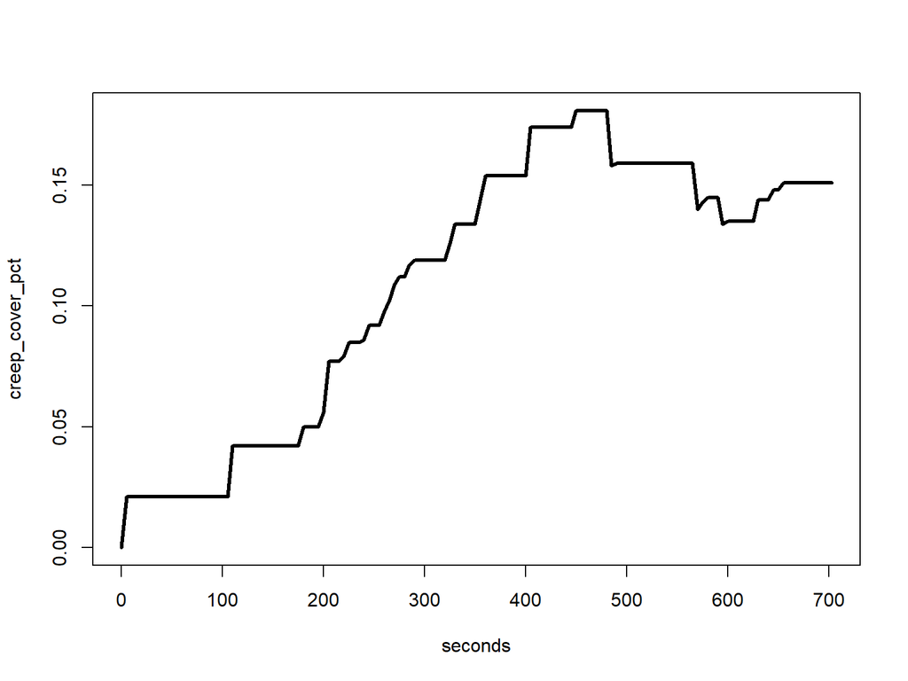

```r
creep_cover_pct = rep(NA, length(tl1$race$creep$coverage))
creep_cover_tiles = rep(NA, length(tl1$race$creep$coverage))

for(k in 1:length(creep_cover_pct))
{
  creep_cover_pct[k] = tl1$race$creep$coverage[[k]][1]
  creep_cover_tiles[k] = tl1$race$creep$coverage[[k]][2]

}

seconds = tl1$gameloop / 112 * 5
plot(y = creep_cover_pct, x=seconds, type="l", lwd=3)
```

# Starcraft 2: Reading the game timeline

There are two types of resources: minerals and gas. Adding up the (mineral + gas) cost of every unit for each player gives us a rough measure of army strength over time. We can plot this for both players.

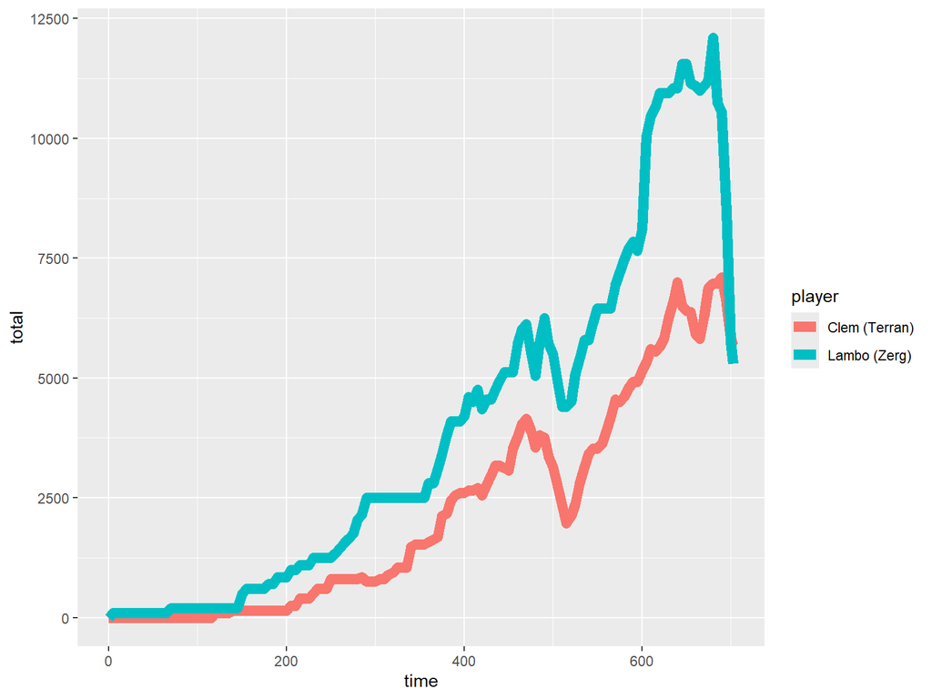

```r
tl1_army = timeline$One$army_value
tl2_army = timeline$Two$army_value
tl1_army$player = "Lambo (Zerg)"
tl2_army$player = "Clem (Terran)"

army_values = rbind(tl1_army, tl2_army)
army_values$time = timeline$One$gameloop / 112 * 5
army_values$total = army_values$minerals + army_values$gas

g = ggplot(data=army_values, aes(x=time, y=total,
                                 group=player, color=player)) +
    geom_line(lwd=3)

plot(g)
```

# Starcraft 2: Future work

- What is the chance of winning at any given time point? (need to also scrape game outcome)
- Is there a turning point when the player’s attention shifts from resource creation to army command?
- What does a typical resource curve look like?
- What are the typical building patterns?

# Starcraft 2: Future work

(Suggestions from William Davis)

- Probably the simplest thing to look into is army value and worker value. Workers are worth future value and army is current assets. If the disparity of army value becomes too great one player wins.
- There is defenders advantage but it scales poorly, starts at a flat number and scales linearly while army values lethality will scale exponentially.
- Army values exponential value will be more linked to gas value rather than minerals.
- EAPM (effective actions per minute) probably has linear returns on success up to a point and then it has diminishing returns.

# Chess and the PGN format

PGN is a format for recording chess matches. The free chess website Lichess has a database of every game played on their servers. (These are VERY large files)

https://database.lichess.org/

This is the example PGN of a single game from that database

```
[Event "Rated Bullet tournament https://lichess.org/tournament/yc1WW2Ox"]
[Site "https://lichess.org/PpwPOZMq"]
[Date "2017.04.01"]
[Round "-"]
[White "Abbot"]
[Black "Costello"]
[Result "0-1"]
[UTCDate "2017.04.01"]
[UTCTime "11:32:01"]
[WhiteElo "2100"]
[BlackElo "2000"]
[WhiteRatingDiff "-4"]
[BlackRatingDiff "+1"]
[WhiteTitle "FM"]
[ECO "B30"]
[Opening "Sicilian Defense: Old Sicilian"]
[TimeControl "300+0"]
[Termination "Time forfeit"]

1. e4 { [%eval 0.17] [%clk 0:00:30] } 1... c5 { [%eval 0.19] [%clk 0:00:30] }
2. Nf3 { [%eval 0.25] [%clk 0:00:29] } 2... Nc6 { [%eval 0.33] [%clk 0:00:30] }
3. Bc4 { [%eval -0.13] [%clk 0:00:28] } 3... e6 { [%eval -0.04] [%clk 0:00:30] }
4. c3 { [%eval -0.4] [%clk 0:00:27] } 4... b5? { [%eval 1.18] [%clk 0:00:30] }
5. Bb3?! { [%eval 0.21] [%clk 0:00:26] } 5... c4 { [%eval 0.32] [%clk 0:00:29] }
6. Bc2 { [%eval 0.2] [%clk 0:00:25] } 6... a5 { [%eval 0.6] [%clk 0:00:29] }
7. d4 { [%eval 0.29] [%clk 0:00:23] } 7... cxd3 { [%eval 0.6] [%clk 0:00:27] }
8. Qxd3 { [%eval 0.12] [%clk 0:00:22] } 8... Nf6 { [%eval 0.52] [%clk 0:00:26] }
9. e5 { [%eval 0.39] [%clk 0:00:21] } 9... Nd5 { [%eval 0.45] [%clk 0:00:25] }
10. Bg5?! { [%eval -0.44] [%clk 0:00:18] } 10... Qc7 { [%eval -0.12] [%clk 0:00:23] }
11. Nbd2?? { [%eval -3.15] [%clk 0:00:14] } 11... h6 { [%eval -2.99] [%clk 0:00:23] }
12. Bh4 { [%eval -3.0] [%clk 0:00:11] } 12... Ba6? { [%eval -0.12] [%clk 0:00:23] }
13. b3?? { [%eval -4.14] [%clk 0:00:02] } 13... Nf4? { [%eval -2.73] [%clk 0:00:21] } 0-1
```

# Chess and the PGN format

Chess games are typically stored in the Portable Game Notation (PGN) format.

First, the format looks a lot like that of JSON or XML. We’re going to start by tackling it manually with text analysis. Next week is all about text analysis, but let’s break down what we can. What can we get from this, reading it as a human?

```
[Event "Rated Bullet tournament https://lichess.org/tournament/yc1WW2Ox"]
[Site "https://lichess.org/PpwPOZMq"]
[Date "2017.04.01"]
[Round "-"]
[White "Abbot"]
[Black "Costello"]
[Result "0-1"]
[UTCDate "2017.04.01"]
[UTCTime "11:32:01"]
```

# Chess and the PGN format

We could extract that with the `stringr` package.

`readLines()` pulls in data to R verbatim. This file is the same example game four times.

# Chess and the PGN format

```r
pgn_ex = readLines("PGN_example.txt")
pgn_ex[1:10]
```

```
##  [1] "[Event \"Rated Bullet tournament https://lichess.org/tournament/yc1WW2Ox\"]"
##  [2] "[Site \"https://lichess.org/PpwPOZMq\"]"
##  [3] "[Date \"2017.04.01\"]"
##  [4] "[Round \"-\"]"
##  [5] "[White \"Abbot\"]"
##  [6] "[Black \"Costello\"]"
##  [7] "[Result \"0-1\"]"
##  [8] "[UTCDate \"2017.04.01\"]"
##  [9] "[UTCTime \"11:32:01\"]"
## [10] "[WhiteElo \"2100\"]"
```

# Chess and the PGN format

Since every variable name has no spaces in these first few parts, we can split these by a space with `str_split_fixed`.

```r
pgn2 = str_split_fixed(pgn_ex, " ", 2)
pgn2[1:25,]
```

```
##       [,1]
##  [1,] "[Event"
##  [2,] "[Site"
##  [3,] "[Date"
##  [4,] "[Round"
##  [5,] "[White"
##  [6,] "[Black"
##  [7,] "[Result"
##  [8,] "[UTCDate"
##  [9,] "[UTCTime"
## [10,] "[WhiteElo"
## [11,] "[BlackElo"
## [12,] "[WhiteRatingDiff"
## [13,] "[BlackRatingDiff"
## [14,] "[WhiteTitle"
```

[output cut: 37 more lines]

# Chess and the PGN format

That worked great for the game metadata, but not the moves. Let’s find a way to isolate the moves. The regular expression `^\\[.*\\]$` means…

- `^` means “Starts with”
- `\\[` First character is literally a `[`. The backslash `\` is an escape character, and we need to double-escape when using `str_xxx` functions because they call to another more primitive called `grep`.
- `.` is a wildcard. It could be ANY character
- `*` is “any number of”, including zero. So `.*` means `any string of any length`
- `\\]` is the character at the end of the wildcard string.
- `$` means “ends with”, so anything with both `^` and `$` implies the entire string must match the pattern.

# Chess and the PGN format

Therefore, the regular expression `^\\[.*\\]$` means… “Starts with [, and ends with ]”

```r
is_metadata = str_detect(pgn_ex, "^\\[.*\\]$")
is_metadata
```

```
##   [1]  TRUE  TRUE  TRUE  TRUE  TRUE  TRUE  TRUE  TRUE  TRUE  TRUE  TRUE  TRUE
##  [13]  TRUE  TRUE  TRUE  TRUE  TRUE  TRUE FALSE FALSE FALSE FALSE FALSE FALSE
##  [25] FALSE FALSE FALSE FALSE FALSE FALSE FALSE FALSE FALSE  TRUE  TRUE  TRUE
##  [37]  TRUE  TRUE  TRUE  TRUE  TRUE  TRUE  TRUE  TRUE  TRUE  TRUE  TRUE  TRUE
##  [49]  TRUE  TRUE  TRUE FALSE FALSE FALSE FALSE FALSE FALSE FALSE FALSE FALSE
##  [61] FALSE FALSE FALSE FALSE FALSE FALSE FALSE  TRUE  TRUE  TRUE  TRUE  TRUE
##  [73]  TRUE  TRUE  TRUE  TRUE  TRUE  TRUE  TRUE  TRUE  TRUE  TRUE  TRUE  TRUE
##  [85]  TRUE FALSE FALSE FALSE FALSE FALSE FALSE FALSE FALSE FALSE FALSE FALSE
##  [97] FALSE FALSE FALSE FALSE  TRUE  TRUE  TRUE  TRUE  TRUE  TRUE  TRUE  TRUE
## [109]  TRUE  TRUE  TRUE  TRUE  TRUE  TRUE  TRUE  TRUE  TRUE  TRUE FALSE FALSE
## [121] FALSE FALSE FALSE FALSE FALSE FALSE FALSE FALSE FALSE FALSE FALSE FALSE
```

# Chess and the PGN format

Now blank out everything that isn’t metadata. We’ll come back to that stuff later. We want to blank it out and not just subset to remove the lines because we want to keep track of which lines are for which games.

```r
pgn_meta = pgn_ex
pgn_meta[!is_metadata] = ""
pgn_meta2 = str_split_fixed(pgn_meta, " ", 2)
pgn_meta2[1:25,]
```

```
##       [,1]
##  [1,] "[Event"
##  [2,] "[Site"
##  [3,] "[Date"
##  [4,] "[Round"
##  [5,] "[White"
##  [6,] "[Black"
##  [7,] "[Result"
##  [8,] "[UTCDate"
##  [9,] "[UTCTime"
## [10,] "[WhiteElo"
## [11,] "[BlackElo"
## [12,] "[WhiteRatingDiff"
## [13,] "[BlackRatingDiff"
## [14,] "[WhiteTitle"
```

[output cut: 37 more lines]

# Chess and the PGN format

Now remove the `[` in the first one to get the varnames.

```r
vars = str_replace(pgn_meta2[,1], "\\[", "")
varnames = unique(vars)
varnames
```

```
##  [1] "Event"           "Site"            "Date"            "Round"
##  [5] "White"           "Black"           "Result"          "UTCDate"
##  [9] "UTCTime"         "WhiteElo"        "BlackElo"        "WhiteRatingDiff"
## [13] "BlackRatingDiff" "WhiteTitle"      "ECO"             "Opening"
## [17] "TimeControl"     "Termination"     ""
```

```r
vars[1:25]
```

```
##  [1] "Event"           "Site"            "Date"            "Round"
##  [5] "White"           "Black"           "Result"          "UTCDate"
##  [9] "UTCTime"         "WhiteElo"        "BlackElo"        "WhiteRatingDiff"
## [13] "BlackRatingDiff" "WhiteTitle"      "ECO"             "Opening"
## [17] "TimeControl"     "Termination"     ""                ""
## [21] ""                ""                ""                ""
## [25] ""
```

# Chess and the PGN format

Cleaning the values of the variables is harder. How do you remove `"\"` from the beginning and `\"]"` from the end? The answer is often “one step at a time”. **Quotation marks are among the rare excepts to the double-escape rule. If you try to double-escape a quotation mark here, you will get a syntax error.**

```r
values = pgn_meta2[,2]
values[1:20]
```

```
##  [1] "\"Rated Bullet tournament https://lichess.org/tournament/yc1WW2Ox\"]"
##  [2] "\"https://lichess.org/PpwPOZMq\"]"
##  [3] "\"2017.04.01\"]"
##  [4] "\"-\"]"
##  [5] "\"Abbot\"]"
##  [6] "\"Costello\"]"
##  [7] "\"0-1\"]"
##  [8] "\"2017.04.01\"]"
##  [9] "\"11:32:01\"]"
## [10] "\"2100\"]"
## [11] "\"2000\"]"
## [12] "\"-4\"]"
## [13] "\"+1\"]"
## [14] "\"FM\"]"
## [15] "\"B30\"]"
## [16] "\"Sicilian Defense: Old Sicilian\"]"
## [17] "\"300+0\"]"
## [18] "\"Time forfeit\"]"
## [19] ""
## [20] ""
```

```r
# replaces multiple instances. Removes all quotation marks
values = str_replace_all(values, "\"", "")
values[1:20]
```

```
##  [1] "Rated Bullet tournament https://lichess.org/tournament/yc1WW2Ox]"
##  [2] "https://lichess.org/PpwPOZMq]"
##  [3] "2017.04.01]"
##  [4] "-]"
##  [5] "Abbot]"
##  [6] "Costello]"
##  [7] "0-1]"
##  [8] "2017.04.01]"
##  [9] "11:32:01]"
## [10] "2100]"
## [11] "2000]"
## [12] "-4]"
## [13] "+1]"
## [14] "FM]"
## [15] "B30]"
## [16] "Sicilian Defense: Old Sicilian]"
## [17] "300+0]"
## [18] "Time forfeit]"
## [19] ""
## [20] ""
```

```r
# Removes the ] at the end
values = str_replace(values, "\\]$", "")
values[1:20]
```

```
##  [1] "Rated Bullet tournament https://lichess.org/tournament/yc1WW2Ox"
##  [2] "https://lichess.org/PpwPOZMq"
##  [3] "2017.04.01"
##  [4] "-"
##  [5] "Abbot"
##  [6] "Costello"
##  [7] "0-1"
##  [8] "2017.04.01"
##  [9] "11:32:01"
## [10] "2100"
## [11] "2000"
## [12] "-4"
## [13] "+1"
## [14] "FM"
## [15] "B30"
## [16] "Sicilian Defense: Old Sicilian"
## [17] "300+0"
## [18] "Time forfeit"
## [19] ""
## [20] ""
```

# Chess and the PGN format

Great! Now for the hard part: How to parse this?

```r
pgn_ex[20:24]
```

```
## [1] "1. e4 { [%eval 0.17] [%clk 0:00:30] } 1... c5 { [%eval 0.19] [%clk 0:00:30] }"
## [2] "2. Nf3 { [%eval 0.25] [%clk 0:00:29] } 2... Nc6 { [%eval 0.33] [%clk 0:00:30] }"
## [3] "3. Bc4 { [%eval -0.13] [%clk 0:00:28] } 3... e6 { [%eval -0.04] [%clk 0:00:30] }"
## [4] "4. c3 { [%eval -0.4] [%clk 0:00:27] } 4... b5? { [%eval 1.18] [%clk 0:00:30] }"
## [5] "5. Bb3?! { [%eval 0.21] [%clk 0:00:26] } 5... c4 { [%eval 0.32] [%clk 0:00:29] }"
```

The format is

```
MOVENUM. WHITEMOVE { [%eval EVAL] [%clk CLOCK TIME]} MOVENUM... BLACKMOVE { [%eval EVAL] [%clk CLOCK TIME]}
```

# Chess: The bigchess package

We can automatically parse Portable Game Notation (PGN) using `read.pgn()` in the CRAN `bigchess`, so let’s try that.

```r
pgn = read.pgn("chess_classic_games.pgn")
```

```
## 2024-07-03 10:51:14.337847, successfully imported 4994 games
```

```
## 2024-07-03 10:51:14.791765, N moves computed
```

```
## 2024-07-03 10:51:15.387383, extract moves done
```

```
## 2024-07-03 10:51:18.4016, stat moves computed
```

```r
dim(pgn)
```

```
## [1] 4994   49
```

```r
pgn[1,]
```

```
##                                                             Event
## 1 Rated Bullet tournament https://lichess.org/tournament/rs53Xpda
##                           Site       Date Round   White       Black Result
## 1 https://lichess.org/Xa3soL0G 2018.09.30     - YessidP pushka_1995    1-0
##                                                                                                                                                                                                                                                                                                          …
## 1 1. d4 d5 2. Nf3 Nf6 3. e3 e6 4. c4 Be7 5. Nc3 dxc4 6. Bxc4 O-O 7. Bd3 h6 8. Qc2 b6 9. Ne5 Ba6 10. Bxa6 Nxa6 11. a3 Nb8 12. b3 Nfd7 13. Nxd7 Qxd7 14. Bb2 Qc6 15. f3 b5 16. Qe2 a6 17. a4 b4 18. Ne4 Bd6 19. O-O Qd7 20. Nxd6 Qxd6 21. Qc4 Nc6 22. Rfd1 Qd5 23. Qxd5 exd5 24. Rac1 Ne7 25. Rxc7 Nf5 26. …
##   NMoves W1 B1  W2  B2 W3 B3 W4  B4  W5   B5   W6  B6  W7 B7  W8 B8  W9  B9
## 1     38 d4 d5 Nf3 Nf6 e3 e6 c4 Be7 Nc3 dxc4 Bxc4 O-O Bd3 h6 Qc2 b6 Ne5 Ba6
##    W10  B10 last.move complete.movetext W_B_moves W_K_moves W_N_moves W_O_moves
## 1 Bxa6 Nxa6        d7              TRUE         4         1         6         1
##   W_Q_moves W_R_moves B_B_moves B_K_moves B_N_moves B_O_moves B_Q_moves
## 1         4        10         3         2        14         1         5
##   B_R_moves B_moves K_moves N_moves O_moves Q_moves R_moves
## 1         4       7       3      20       2       9      14
```

# Chess: The bigchess package

(Including the package name in the function for disambiguation)

```r
bigchess::extract_moves(pgn$Movetext[1])
```

```
##   W1 B1  W2  B2 W3 B3 W4  B4  W5   B5   W6  B6  W7 B7  W8 B8  W9  B9  W10  B10
## 1 d4 d5 Nf3 Nf6 e3 e6 c4 Be7 Nc3 dxc4 Bxc4 O-O Bd3 h6 Qc2 b6 Ne5 Ba6 Bxa6 Nxa6
##   last.move complete.movetext
## 1        d7              TRUE
```

```r
bigchess::extract_moves(pgn$Movetext[1], N=50)
```

```
##   W1 B1  W2  B2 W3 B3 W4  B4  W5   B5   W6  B6  W7 B7  W8 B8  W9  B9  W10  B10
## 1 d4 d5 Nf3 Nf6 e3 e6 c4 Be7 Nc3 dxc4 Bxc4 O-O Bd3 h6 Qc2 b6 Ne5 Ba6 Bxa6 Nxa6
##   W11 B11 W12  B12  W13  B13 W14 B14 W15 B15 W16 B16 W17 B17 W18 B18 W19 B19
## 1  a3 Nb8  b3 Nfd7 Nxd7 Qxd7 Bb2 Qc6  f3  b5 Qe2  a6  a4  b4 Ne4 Bd6 O-O Qd7
##    W20  B20 W21 B21  W22 B22  W23  B23  W24 B24  W25 B25 W26 B26  W27 B27 W28
## 1 Nxd6 Qxd6 Qc4 Nc6 Rfd1 Qd5 Qxd5 exd5 Rac1 Ne7 Rxc7 Nf5  e4 Nd6 exd5 Nf5  d6
##    B28 W29  B29 W30 B30 W31 B31 W32 B32 W33 B33 W34 B34  W35  B35   W36  B36
## 1 Nxd6  d5 Rac8 Rd7 Nf5  g4 Ne3 Re1 Nc2 Re2  g6  d6 Na3 Rde7 Rfe8 Rxe8+ Rxe8
##     W37 B37 W38  B38  W39  B39  W40  B40  W41  B41  W42  B42  W43  B43  W44
## 1 Rxe8+ Kh7  d7 <NA> <NA> <NA> <NA> <NA> <NA> <NA> <NA> <NA> <NA> <NA> <NA>
##    B44  W45  B45  W46  B46  W47  B47  W48  B48  W49  B49  W50  B50 last.move
## 1 <NA> <NA> <NA> <NA> <NA> <NA> <NA> <NA> <NA> <NA> <NA> <NA> <NA>        d7
##   complete.movetext
## 1              TRUE
```

# Chess: The bigchess package

```r
table(bigchess::extract_moves(pgn$Movetext)$W1)
```

```
##
##   a3   a4   b3   b4   c3   c4   d3   d4   e3   e4   f3   f4   g3   g4   h3   h4
##    7    4   68   17    6  170   46 1334   93 2868    6   47   86   13    3   10
##  Na3  Nc3  Nf3  Nh3
##    1   28  176    1
```

```r
table(bigchess::extract_moves(pgn$Movetext)$W1) / nrow(pgn)
```

```
##
##           a3           a4           b3           b4           c3           c4
## 0.0014016820 0.0008009612 0.0136163396 0.0034040849 0.0012014417 0.0340408490
##           d3           d4           e3           e4           f3           f4
## 0.0092110533 0.2671205447 0.0186223468 0.5742891470 0.0012014417 0.0094112936
##           g3           g4           h3           h4          Na3          Nc3
## 0.0172206648 0.0026031237 0.0006007209 0.0020024029 0.0002002403 0.0056067281
##          Nf3          Nh3
## 0.0352422907 0.0002002403
```

# Chess: The bigchess package

We can bring in an in-depth analysis with an external chess engine. Stockfish is quite powerful, and it’s open source and available for free at https://stockfishchess.org/download/ . Just put the .exe file that the download comes with into your working directory and call it.

`G[[n]]` is the `n`th move in the game.

```r
G <- analyze_game(engine = "stockfish-windows-x86-64-avx2.exe",
                  san = pgn$Movetext[1] ,depth = 20)
```

[output not shown]

[output not shown]

[output not shown]

[output not shown]

[output not shown]

[output not shown]

[output not shown]

[output not shown]

[output not shown]

[output not shown]

[output not shown]

[output not shown]

[output not shown]

[output not shown]

[output not shown]

[output not shown]

[output not shown]

[output not shown]

[output not shown]

[output not shown]

[output not shown]

[output not shown]

[output not shown]

[output not shown]

[output not shown]

[output not shown]

[output not shown]

[output not shown]

[output not shown]

[output not shown]

[output not shown]

[output not shown]

[output not shown]

[output not shown]

[output not shown]

[output not shown]

[output not shown]

[output not shown]

[output not shown]

[output not shown]

[output not shown]

[output not shown]

[output not shown]

[output not shown]

[output not shown]

[output not shown]

[output not shown]

[output not shown]

[output not shown]

[output not shown]

[output not shown]

[output not shown]

[output not shown]

[output not shown]

[output not shown]

[output not shown]

[output not shown]

[output not shown]

[output not shown]

[output not shown]

[output not shown]

[output not shown]

[output not shown]

[output not shown]

[output not shown]

[output not shown]

[output not shown]

[output not shown]

[output not shown]

[output not shown]

[output not shown]

[output not shown]

[output not shown]

[output not shown]

[output not shown]

```
## Done!
```

```r
G[[1]]
```

```
## $curmove_lan
## [1] "d2d4"
##
## $curmove_san
## [1] "d4"
##
## $curpos_lan
## [1] "d2d4"
##
## $curpos_san
## [1] "1. d4"
##
## $comment
## [1] "book"
```

```r
G[[2]]
```

```
## $curmove_lan
## [1] "d7d5"
##
## $curmove_san
## [1] "d5"
##
## $curpos_lan
## [1] "d2d4 d7d5"
##
## $curpos_san
## [1] "1. d4 d5"
##
## $comment
## [1] "book"
```

```r
G[[10]]$score
```

```
## [1] 32
```

```r
G[[20]]$score
```

```
## [1] 1
```

```r
G[[10]]$bestmove
```

```
## [1] "f8e7" "b2b3" "e8g8" "f1c4"
```

```r
G[[20]]$bestmove
```

```
##  [1] "f8e7" "b2b3" "e8g8" "f1c4" "c7c5" "d1e2" "c7c5" "e3e4" "c7c5" "e1g1"
## [11] "c8b7" "d3a6" "b8a6" "c2e2"
```

# Chess: The chessR package

We can also use the chessR package

https://github.com/JaseZiv/chessR

https://jaseziv.github.io/chessR/articles/using_chessR_package.html

https://jaseziv.github.io/chessR/reference/index.html

`devtools::install_github("JaseZiv/chessR")`

# Chess: The chessR package

We can `get_raw_lichess` which is like what we have, but in a data.frame.

```r
lichess_game_data <- get_raw_lichess("Georges")
lichess_game_data[1,]
```

```
##               Event                         Site       Date    White   Black
## 1 Casual rapid game https://lichess.org/lmudvufi 2013.07.13 baninoyz georges
##   Result    UTCDate  UTCTime WhiteElo BlackElo  Variant TimeControl ECO
## 1    1-0 2013.07.13 18:31:50     1325     1248 Standard       900+1 B12
##             Opening  Termination
## 1 Caro-Kann Defense Time forfeit
##                                                                                                                                                                                                                                                                                                          …
## 1 1. e4 c6 2. d4 g5 3. Bxg5 h6 4. Bf4 Bg7 5. Nf3 Nf6 6. Bd3 d5 7. e5 Ne4 8. Nbd2 Bf5 9. O-O Nxd2 10. Qxd2 Bxd3 11. cxd3 Nd7 12. e6 Nf6 13. exf7+ Kxf7 14. Rae1 Qg8 15. Ne5+ Ke8 16. Qb4 Bf8 17. Qxb7 Rd8 18. Nxc6 Rd7 19. Qc8+ Kf7 20. Ne5+ Kg7 21. Nxd7 Rh7 22. Be5 Qf7 23. Re3 Kg8 24. Bxf6 exf6 25. Nx…
##   WhiteRatingDiff BlackRatingDiff Username
## 1            <NA>            <NA>  Georges
```

```r
chessR::extract_moves(lichess_game_data$Moves[1])
```

```
##         white     black
## 1       e4 c6     d4 g5
## 2     Bxg5 h6   Bf4 Bg7
## 3     Nf3 Nf6    Bd3 d5
## 4      e5 Ne4  Nbd2 Bf5
## 5    O-O Nxd2 Qxd2 Bxd3
## 6    cxd3 Nd7    e6 Nf6
## 7  exf7+ Kxf7  Rae1 Qg8
## 8    Ne5+ Ke8   Qb4 Bf8
## 9    Qxb7 Rd8  Nxc6 Rd7
## 10   Qc8+ Kf7  Ne5+ Kg7
## 11   Nxd7 Rh7   Be5 Qf7
## 12    Re3 Kg8 Bxf6 exf6
## 13  Nxf8 Qxf8  Re8 Qxe8
## 14      Qxe8+
```

# Chess: The chessR package

We can extract the moves from the pgn with our manual text processing

```r
pgn_ex_moves = paste(pgn_ex[20:32], collapse = " ")
pgn_ex_moves
```

```
## [1] "1. e4 { [%eval 0.17] [%clk 0:00:30] } 1... c5 { [%eval 0.19] [%clk 0:00:30] } 2. Nf3 { [%eval 0.25] [%clk 0:00:29] } 2... Nc6 { [%eval 0.33] [%clk 0:00:30] } 3. Bc4 { [%eval -0.13] [%clk 0:00:28] } 3... e6 { [%eval -0.04] [%clk 0:00:30] } 4. c3 { [%eval -0.4] [%clk 0:00:27] } 4... b5? { [%ev…
```

```r
chessR::extract_moves(pgn_ex_moves)
```

```
##     white black
## 1      e4    c5
## 2     Nf3   Nc6
## 3     Bc4    e6
## 4      c3   b5?
## 5   Bb3?!    c4
## 6     Bc2    a5
## 7      d4  cxd3
## 8    Qxd3   Nf6
## 9      e5   Nd5
## 10  Bg5?!   Qc7
## 11 Nbd2??    h6
## 12    Bh4  Ba6?
## 13   b3??  Nf4?
```